# Supervised Learning - Ensemble Methods

Liah Cha

June 28, 2017

## Instability

- 꼭 Decisin Tree에 쓰라는 법은 없지만, DT에 사용했을때 효과가 가장 좋음 - DT의 단점(Instability, 불안정성)
  - 데이터가 약간만 변해도 DT가 완전히 바뀔 수 있음
  - 즉 DT의 모양이 자주 바뀜 -> 변동성이 큼 -> 분산이 크다(High Variance)
  - bias는 작다 (training 데이터의 에러는 작은 편이다, overfitting 할 수 있기 때문)
  - accuracy 측면에서는 분산이 작아야 좋음
- High variance, Low bias
  - DT는 분산이 크나, bias는 작음
- High bias, Low variance
  - LR은 분산은 작으나(변동성이 적음), bias는 클 수 있음

#### Variance in classification

- For a fixed classification method, if a new data set (size N) is sampled,
- The learned classifier f will be different
- The variance measures the sensitivity of f to changes in the training set
- variance decreases with N
- variance increases with complexity (high for overfitted models)

#### Bias in classification

- When the classifier *f* is too simple it cannot fit the data well, no matter which *f* we choose
- Buas cab be
  - Deterministic (hard): no *f* fits the data
  - Stochastic (soft): the probability of learning an *f* that fits the data is very small

## Two types of classifier

- Unstable Classifiers
  - Decision, Trees, Neural Network
- Stable Classifiers +Low variance, relatively high bias

안정적(variance도 낮고)이면서도 bias도 낮은것 -> 미래 데이터에 대한 accuracy가 가장 정확할 것

- Ensemble : DT의 variance를 낮추기 위함

variance(x) = $\sigma^{2}$ variance($\bar{X}$ = $\frac{\sigma^{2}}{n}$)

여러개 DT 성과들의 평균

## #### Combining multipe models

- bagging, boosting, random forest

## Bagging

- 최소 50개 많게는 100개의 DT를 만들어냄
- training data를 purturb 시켜(약간 변형시켜) 만들어냄 : Bootstrap으로
  - 재추출 (with replacement) : 뽑힌놈이 또 뽑힐수도 있음
  - 즉, sampling w/replacement
  - Bootstrap을 최소 50번 해줌 -> Bootstrap data를 50개-100개 만들어 줌

#### 앙상블 성공요건

1. 100개의 트리가 다양해야 함 (다양성) –> Bagging
   - 트리의 결과가 비슷비슷하면 다수결 할 필요도 없음
2. 100개의 트리가 정확해야 함 (정확성)
- Random Forest(현존하는 3대 정확한 기법중 하나) : Bagging 을 기반으로 함

##### Bagging: approximate the margin

## Example : German Credit

```r
### Ensemble ###
setwd("C:/DMdata")
german = read.table("germandata.txt",header=T)
german$numcredits = factor(german$numcredits)
german$residence = factor(german$residence)
german$residpeople = factor(german$residpeople)
summary(german)
```

```
##  check        duration    history      purpose        credit
##  A11:274   Min.   : 4.0   A30: 40   A43    :280   Min.   :  250
##  A12:269   1st Qu.:12.0   A31: 49   A40    :234   1st Qu.: 1366
##  A13: 63   Median :18.0   A32:530   A42    :181   Median : 2320
##  A14:394   Mean   :20.9   A33: 88   A41    :103   Mean   : 3271
##            3rd Qu.:24.0   A34:293   A49    : 97   3rd Qu.: 3972
##            Max.   :72.0             A46    : 50   Max.   :18424
##                                     (Other): 55
##  savings   employment  installment    personal  debtors    residence
##  A61:603   A71: 62    Min.   :1.000   A91: 50   A101:907   1:130
##  A62:103   A72:172    1st Qu.:2.000   A92:310   A102: 41   2:308
##  A63: 63   A73:339    Median :3.000   A93:548   A103: 52   3:149
##  A64: 48   A74:174    Mean   :2.973   A94: 92              4:413
##  A65:183   A75:253    3rd Qu.:4.000
##                       Max.   :4.000
##
##  property        age         others    housing    numcredits   job
##  A121:282   Min.   :19.00   A141:139   A151:179   1:633      A171: 22
##  A122:232   1st Qu.:27.00   A142: 47   A152:713   2:333      A172:200
##  A123:332   Median :33.00   A143:814   A153:108   3: 28      A173:630
##  A124:154   Mean   :35.55                         4:  6      A174:148
##             3rd Qu.:42.00
##             Max.   :75.00
##
##  residpeople telephone  foreign       y
##  1:845       A191:596   A201:963   bad :300
##  2:155       A192:404   A202: 37   good:700
##
##
##
##
##
```

```r
#install.packages("adabag",repos="http://healthstat.snu.ac.kr/CRAN/")

##### Bagging
library(rpart)
library(adabag)
library(pROC)
set.seed(1234) #bootstrap을 위해 필수
#xval=0 ; cross-validation 안함-즉 pruning을 안함-> bagging에서는 tree 사이즈 큰 것이 좋음 (training data 정확도를 높이기 위해)
#minsplit => node크기 5까지
#maxdepth => 깊이 10까지
my.control <- rpart.control(xval=0, cp=0, minsplit=5, maxdepth=10)

# mfinal => 트리를 몇개 만들 것인지 크기 (voting을 위해 홀수가 좋음, 동점이 나면 random하게 함 )
bag.german <- bagging(y ~ ., data = german, mfinal=50, control=my.control)
summary(bag.german)
```

```
##            Length Class   Mode
## formula        3  formula call
## trees         50  -none-  list
## votes       2000  -none-  numeric
## prob        2000  -none-  numeric
## class       1000  -none-  character
## samples    50000  -none-  numeric
## importance    20  -none-  numeric
## terms          3  terms   call
## call           5  -none-  call
```

```r
print(bag.german$importance)
```

```
##         age       check      credit     debtors    duration  employment
##  7.43469852 15.58941140 12.08466253  2.03306221 10.47429493  6.41006079
##     foreign     history     housing installment         job  numcredits
##  0.05013736  7.01523633  1.25069425  2.53622702  2.04513640  0.82949767
##      others    personal    property     purpose   residence residpeople
##  2.55467294  3.17534043  4.29339858 11.47569935  3.77050194  0.34700588
##     savings   telephone
##  5.95283093  0.67743053
```

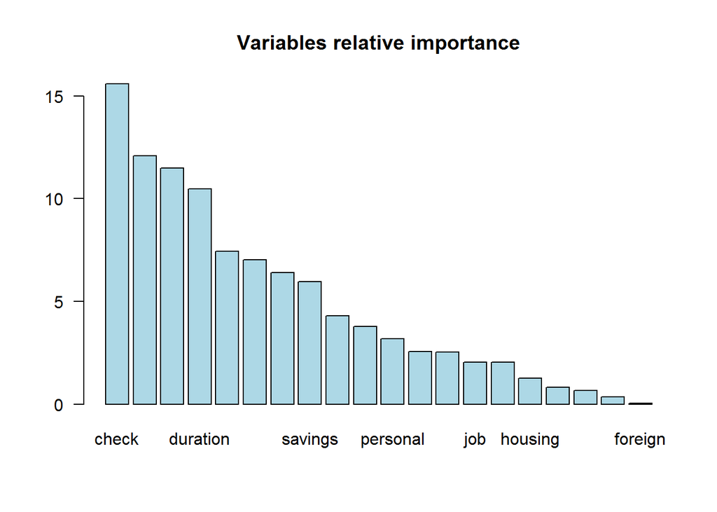

```r
importanceplot(bag.german)
```

```r
head(bag.german$votes) #50개 각각의 투표 결과
```

```
##      [,1] [,2]
## [1,]   13   37
## [2,]   18   32
## [3,]   12   38
## [4,]   12   38
## [5,]   15   35
## [6,]   15   35
```

```r
#head(bag.german$class)
```

```r
# test data는 다른 것을 써줘야함 (여기서는 우선 german으로 활용)
pred.bag.german <- predict.bagging(bag.german, newdata=german)
head(pred.bag.german$prob,10)
```

```
##       [,1] [,2]
##  [1,] 0.02 0.98
##  [2,] 0.94 0.06
##  [3,] 0.00 1.00
##  [4,] 0.40 0.60
##  [5,] 0.66 0.34
##  [6,] 0.10 0.90
##  [7,] 0.00 1.00
##  [8,] 0.28 0.72
##  [9,] 0.00 1.00
## [10,] 0.88 0.12
```

```r
print(pred.bag.german$confusion) # confusion matrix
```

```
##                Observed Class
## Predicted Class bad good
##            bad  263    2
##            good  37  698
```

```r
1-sum(diag(pred.bag.german$confusion))/sum(pred.bag.german$confusion)
```

```
## [1] 0.039
```

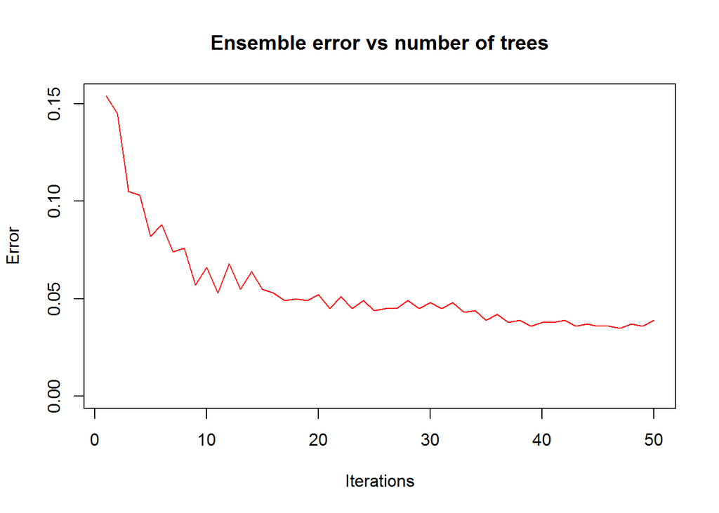

```r
evol.german=errorevol(bag.german, newdata=german)
plot.errorevol(evol.german)
```

- tree의 갯수에 따라 error가 줄어드는 것을 볼 수 있음

```r
#####Fitting by training data and validating by test data
set.seed(1234)
i = sample(1:nrow(german), round(nrow(german)*0.7)) #70% for training data, 30% for testdata
german.train = german[i,]
german.test = german[-i,]
my.control <- rpart.control(xval=0, cp=0, minsplit=5, maxdepth=10)
bag.train.german <- bagging(y ~ ., data = german.train, mfinal=50, control=my.control)
pred.bag.german <- predict.bagging(bag.train.german, newdata=german.test)
print(pred.bag.german$confusion)
```

```
##                Observed Class
## Predicted Class bad good
##            bad   44   24
##            good  55  177
```

```r
1-sum(diag(pred.bag.german$confusion))/sum(pred.bag.german$confusion)
```

```
## [1] 0.2633333
```

```r
head(pred.bag.german$prob)
```

```
##      [,1] [,2]
## [1,] 0.52 0.48
## [2,] 0.62 0.38
## [3,] 0.00 1.00
## [4,] 0.50 0.50
## [5,] 0.74 0.26
## [6,] 0.68 0.32
```

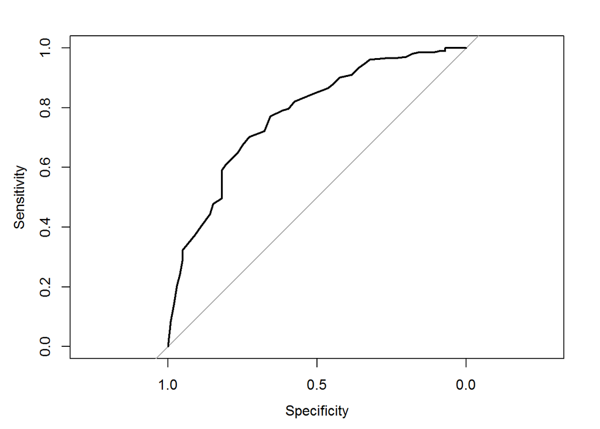

```r
roccurve <- roc(german.test$y ~ pred.bag.german$prob[,1])
plot(roccurve)
```

```r
auc(roccurve)
```

```
## Area under the curve: 0.7757
```

## Random Forest

1. Bootstrap 100-200 반복 => Tree 생성
2. (Bagging 과의 차이점 ) Tree의 다양성
   - 원래 데이터의 변수=[X1, X2, …. , X100]
   - 모든 node마다 동일하게 Greedy search로 분할하는 것은 동일하나,
   - random 하게 변수를 추려 부분집합을 만들어서 진행함
   - 즉, 변수의 부분집합을 추려서 (예:[X2, X7, … , X99]) Greedy Search로 분할함  
     => Bagging 의 트리보다 월등히 많이 다양하게 됨. 즉 트리가 굉장히 다양해짐
- Bagging 과 아주 유사하지만, 각 Tree의 정확성은 유지되면서 다양성이 더 많이 확보됨
  - -> Tree를 만들어내는 단계에서 randomness 가 들어감 (변수 선택할때)
  - 앙상블 성공요건인 “다양성” “정확성”을 모두 갖춤

```r
##### Random Forest
install.packages("randomForest",repos="http://healthstat.snu.ac.kr/CRAN/")
library(randomForest)
set.seed(1234)
rf.german <- randomForest(y ~ ., data = german, ntree=100, mtry=5,
importance=T, na.action=na.omit) # missing value 허용 안하게 짜놓은 package임
summary(rf.german)
```

```
##                 Length Class  Mode
## call               7   -none- call
## type               1   -none- character
## predicted       1000   factor numeric
## err.rate         300   -none- numeric
## confusion          6   -none- numeric
## votes           2000   matrix numeric
## oob.times       1000   -none- numeric
## classes            2   -none- character
## importance        80   -none- numeric
## importanceSD      60   -none- numeric
## localImportance    0   -none- NULL
## proximity          0   -none- NULL
## ntree              1   -none- numeric
## mtry               1   -none- numeric
## forest            14   -none- list
## y               1000   factor numeric
## test               0   -none- NULL
## inbag              0   -none- NULL
## terms              3   terms  call
```

```r
importance(rf.german, type=1) # variable selection으로 쓸 수 있음
```

```
##             MeanDecreaseAccuracy
## check                 18.0148656
## duration               9.5794349
## history                7.6776944
## purpose                3.9161902
## credit                 7.2334246
## savings                3.8829899
## employment             2.2795093
## installment            1.1351249
## personal               1.1850620
## debtors                4.1105380
## residence              0.3222008
## property               3.7180611
## age                    2.7202775
## others                 5.7872698
## housing                2.0355491
## numcredits             2.8526265
## job                    1.4895642
## residpeople           -0.8296497
## telephone              2.7718689
## foreign                1.2827136
```

```r
pred.rf.german <- predict(rf.german, newdata=german)
head(pred.rf.german,10)
```

```
##    1    2    3    4    5    6    7    8    9   10
## good  bad good good  bad good good good good  bad
## Levels: bad good
```

```r
tab=table(german$y,pred.rf.german, dnn=c("Actual","Predicted"))
print(tab)
```

```
##       Predicted
## Actual bad good
##   bad  300    0
##   good   0  700
```

```r
1-sum(diag(tab))/sum(tab)
```

```
## [1] 0
```

#### OOB error

- out-of-bag
  - (n=100 가정) bootstrap을 하면 중복 추출이 된 것이 많음
  - 100개 중에 100개를 뽑을 때 재추출(중복 추출)을 허용하므로
  - 63.2%가 unique한 관찰값이고 36.8%정도가 unique 한 데이터가 됨 (알려진 값)
  - 이 37%를 OOB 데이터라고 함
- 즉 bagging 이 100개라면, OOB도 100개임
- OOB 데이터로 테스트를 해보면 제3데이터 역할을 하므로(해당 tree 만들때 포함되지 않았기 때문에) TEST데이터로 활용해본 것

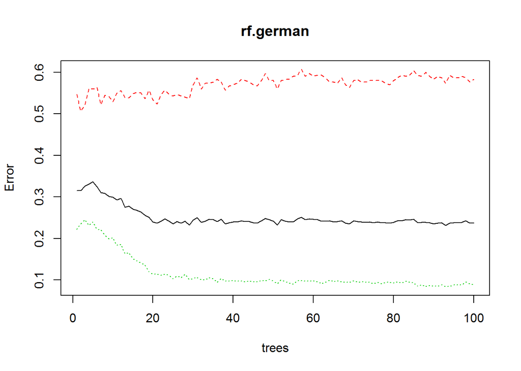

```r
### default로 OOB 데이터의 error를 보여줌
plot(rf.german,type="l")
```

```r
#####Fitting by training data and validating by test data
set.seed(1234)
i = sample(1:nrow(german), round(nrow(german)*0.7)) #70% for training data, 30% for testdata
german.train = german[i,]
german.test = german[-i,]
rf.train.german <- randomForest(y ~ ., data = german.train, ntree=100, mtry=5,
importance=T, na.action=na.omit)
pred.rf.german <- predict(rf.train.german, newdata=german.test)
tab=table(german.test$y,pred.rf.german, dnn=c("Actual","Predicted"))
print(tab)
```

```
##       Predicted
## Actual bad good
##   bad   38   61
##   good  21  180
```

```r
1-sum(diag(tab))/sum(tab)
```

```
## [1] 0.2733333
```

```r
prob.rf.german <- predict(rf.train.german, newdata=german.test, type="prob")
head(prob.rf.german)
```

```
##     bad good
## 4  0.47 0.53
## 5  0.59 0.41
## 7  0.05 0.95
## 8  0.40 0.60
## 11 0.72 0.28
## 15 0.63 0.37
```

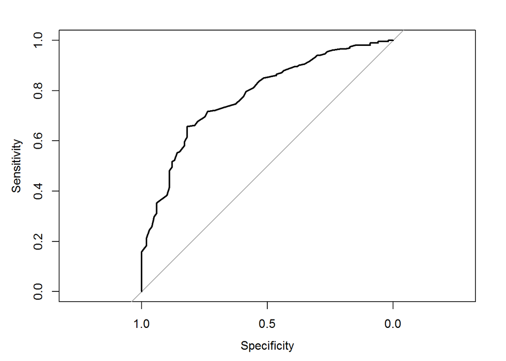

```r
roccurve <- roc(german.test$y ~ prob.rf.german[,1])
plot(roccurve)
```

```r
auc(roccurve)
```

```
## Area under the curve: 0.7804
```

## Boosting

- bootstrap을 사용하지 않는 방법
- 데이터 가중치 변형에 의한 트리 생성
- Training 데이터에서 오분류된 것의 가중치를 변경함
  - 전체 가중치 합이 1이 되어야 하니까, 나머지 데이터의 가중치가 줄어듬
- Greedy 서치를 할때 가중치를 반영한 서치를 함
- 직전 단계에서 error가 있었던 데이터의 가중치를 키워줌 (나머지는 줄이고)
- 가중치 변형을 할때마다 Tree를 생성함 -> 목적은 동일함 100개의 다양한 트리를 생성함

## Adaboost

- Boosting이 알고리즘 방법이라면 구현한 package를 Adaboost라 할 수 있음

```r
##### Boosting
library(rpart)
library(adabag)
set.seed(1234)
# maxdepth=1; 한번만 split 한 Tree
# 가중치의 값에 영향을 주기때문, mxdepth=2,3정도가 좋음
my.control <- rpart.control(xval=0, cp=0, maxdepth=1)
# mfinal=100, 트리의 갯수는 100개
boo.german <- boosting(y ~ ., data = german, boos=T, mfinal=100, control=my.control)
summary(boo.german)
```

```
##            Length Class   Mode
## formula       3   formula call
## trees       100   -none-  list
## weights     100   -none-  numeric
## votes      2000   -none-  numeric
## prob       2000   -none-  numeric
## class      1000   -none-  character
## importance   20   -none-  numeric
## terms         3   terms   call
## call          6   -none-  call
```

```r
boo.german$trees
```

[output not shown]

[output cut: 944 more lines]

[output not shown]

```r
print(boo.german$importance)
```

```
##         age       check      credit     debtors    duration  employment
##  3.62661389 39.53149839  6.95797521  0.11745878 14.55720450  2.80216579
##     foreign     history     housing installment         job  numcredits
##  0.07183044 13.73025824  0.15328957  2.54068951  0.00000000  0.00000000
##      others    personal    property     purpose   residence residpeople
##  1.58312170  1.78330194  1.19549766  7.62528981  0.44113399  0.00000000
##     savings   telephone
##  3.17606414  0.10660643
```

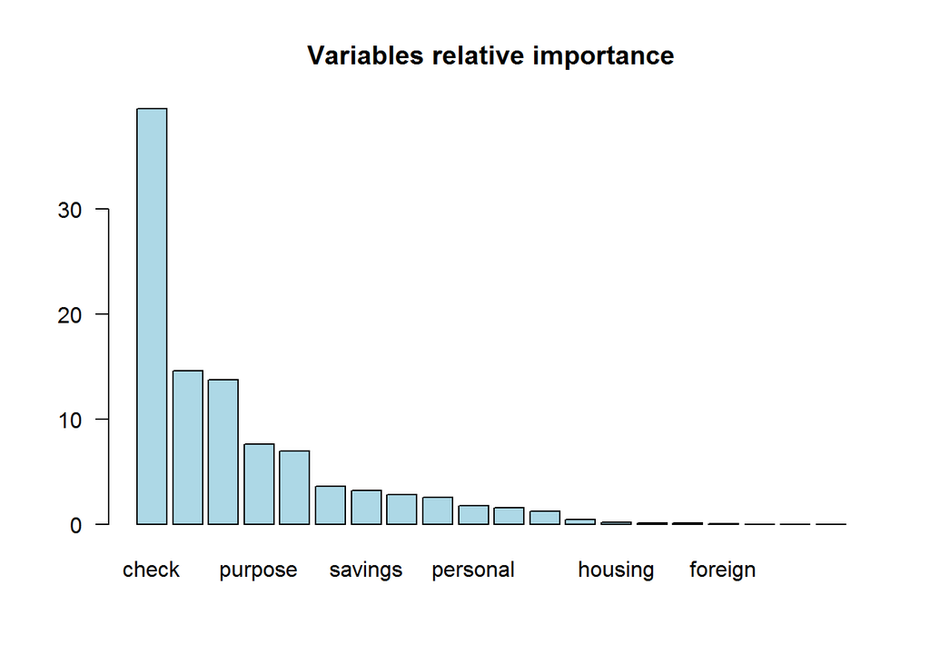

```r
importanceplot(boo.german)
```

```r
pred.boo.german <- predict.boosting(boo.german, newdata=german)
head(pred.boo.german$prob,10)
```

```
##            [,1]      [,2]
##  [1,] 0.2804055 0.7195945
##  [2,] 0.5393438 0.4606562
##  [3,] 0.1809837 0.8190163
##  [4,] 0.5022101 0.4977899
##  [5,] 0.5807079 0.4192921
##  [6,] 0.3343870 0.6656130
##  [7,] 0.2096976 0.7903024
##  [8,] 0.4121435 0.5878565
##  [9,] 0.1146424 0.8853576
## [10,] 0.5362397 0.4637603
```

```r
print(pred.boo.german$confusion)
```

```
##                Observed Class
## Predicted Class bad good
##            bad  150   65
##            good 150  635
```

```r
1-sum(diag(pred.boo.german$confusion))/sum(pred.boo.german$confusion)
```

```
## [1] 0.215
```

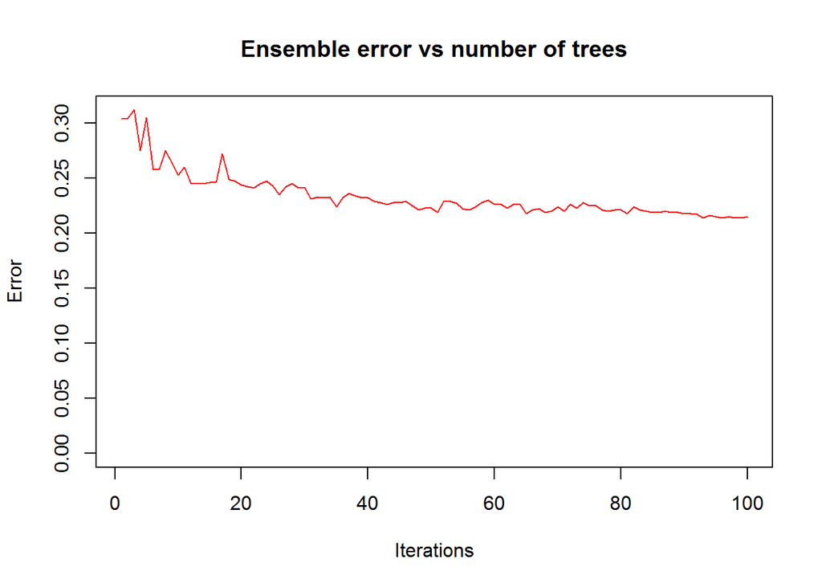

```r
evol.german=errorevol(boo.german, newdata=german)
plot.errorevol(evol.german)
```

```r
#####Fitting by training data and validating by test data
set.seed(1234)
i = sample(1:nrow(german), round(nrow(german)*0.7)) #70% for training data, 30% for testdata
german.train = german[i,]
german.test = german[-i,]
my.control <- rpart.control(xval=0, cp=0, maxdepth=1)
boo.train.german <- boosting(y ~ ., data = german.train, boos=T, mfinal=100, control=my.control)
pred.boo.german <- predict.boosting(boo.train.german, newdata=german.test)
print(pred.boo.german$confusion)
```

```
##                Observed Class
## Predicted Class bad good
##            bad   42   19
##            good  57  182
```

```r
1-sum(diag(pred.boo.german$confusion))/sum(pred.boo.german$confusion)
```

```
## [1] 0.2533333
```

```r
head(pred.boo.german$prob)
```

```
##           [,1]      [,2]
## [1,] 0.5335729 0.4664271
## [2,] 0.5653057 0.4346943
## [3,] 0.1927560 0.8072440
## [4,] 0.4612876 0.5387124
## [5,] 0.5220164 0.4779836
## [6,] 0.5081738 0.4918262
```

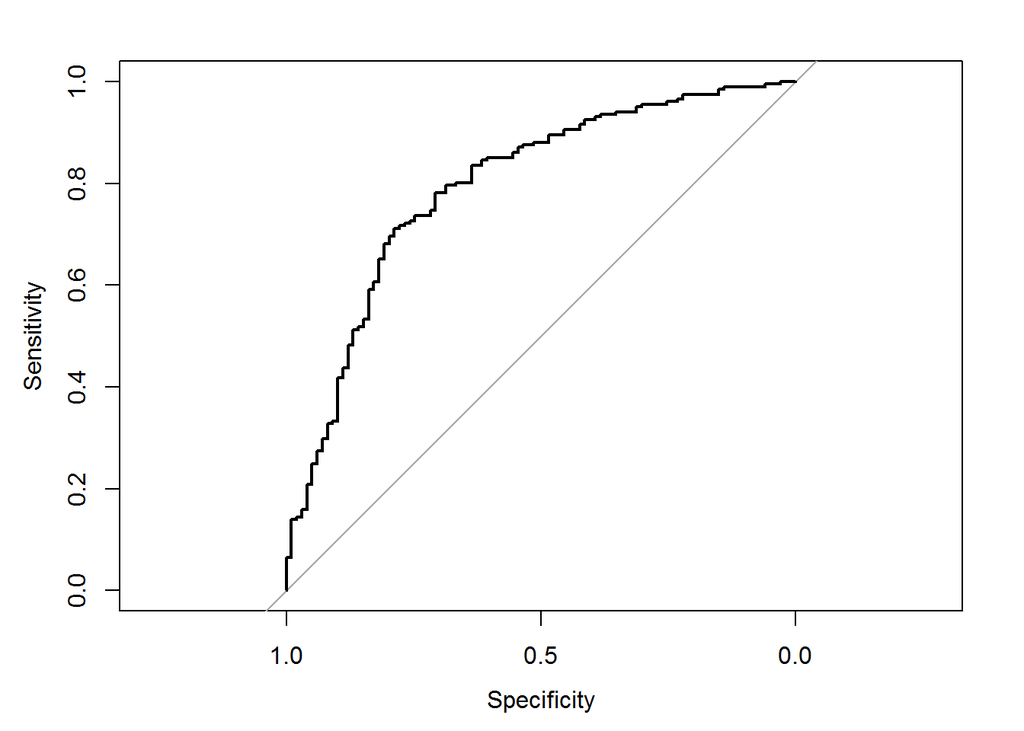

```r
roccurve <- roc(german.test$y ~ pred.boo.german$prob[,1])
plot(roccurve)
```

```r
auc(roccurve)
```

```
## Area under the curve: 0.794
```